# 5. Derechos y obligaciones en relación a la Salud

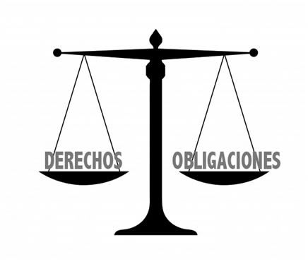

Fuente: Pinterest. La salud es un derecho pero también implica obligaciones.

## ¿Qué es el derecho a la salud?

El derecho a la salud es un **derecho humano fundamental**. Significa que **todas las personas deben poder acceder a servicios de salud adecuados, oportunos y de calidad**, sin discriminación.

También es importante considerar que los derechos normalmente suponen obligaciones, no solo para el Estado sino también para los individuos. En el caso del derecho a la salud, esto implica el deber personal de cuidarse a uno mismo, de proteger la salud de quienes nos rodean, y de contribuir al bienestar colectivo.

El derecho a la salud no es un permiso para desentenderse del propio cuerpo, sino todo lo contrario: es una invitación a asumir un compromiso activo. Cada persona tiene responsabilidades como:

- Alimentarse adecuadamente.
- Evitar conductas de riesgo (como el consumo excesivo de alcohol, tabaco u otras drogas).
- Cumplir con esquemas de vacunación y controles médicos.
- Cuidar la salud mental.
- Actuar con responsabilidad frente a enfermedades transmisibles (como el uso del barbijo durante una pandemia).

## Actividad 1: La salud en nuestro pais

Ahora verás como se establece el derecho a la salud y como se organiza el sistema de salud en nuestro pais. Primero copia estas preguntas que deberás responder “brevisimamente” en base a este [video](https://www.youtube.com/watch?v=KaU_OhmarlA).

- **1)** ¿Cuáles son los artículos de la Constitución Nacional en donde encontramos el derecho a la salud?
- **2)** Nombrar los tres subsistemas de salud que existen en Argentina
- **3)** Nombrar otras 3 formas de acceder a servicios de salud.
- **4)** Tu opinión brevemente: ¿Se puede decir que en Argentina todas las personas pueden acceder a servicios de salud?

## Actividad 2

Elige uno de los subsistemas de salud (pregunta b) o de las otras formas de acceder a la salud (pregunta c). Investiga por tu cuenta y escribe un resumen de 5 renglones sobre como funcionan. Una primera fuente de información es el video pero puede buscar otras.

## Salud y desarrollo social

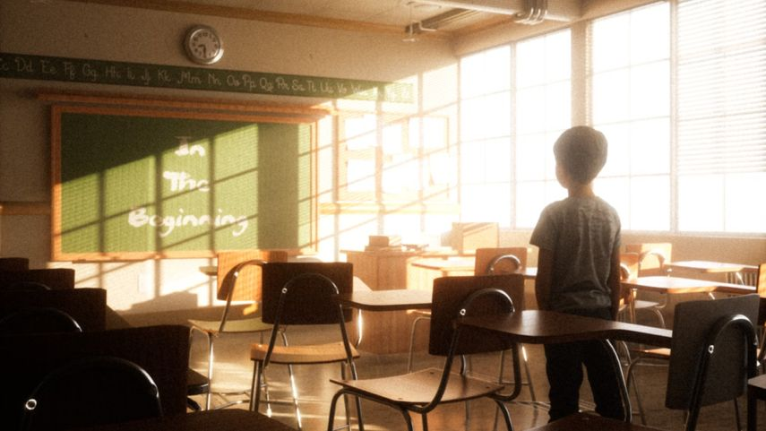

Fuente: www.telemetro.com. En Japón casi no hay niños y se cierran muchas escuelas. ¿Qué tiene que ver esto con la salud?

Recuerda, como lo viste en la unidad anterior, que una persona saludable no es la que no tiene ninguna enfermedad sino la que puede manejar los desafíos que plantea la vida. Si tienes salud entonces puedes encarar los desafíos del trabajo, de la familia, de tu entorno. Y ésto impacta en toda la sociedad y contribuye a mejorarla.

Es importante que un pais tenga un sistema razonablemente bueno de salud pública y eso contribuye a mejorar la calidad de vida y la productividad de los ciudadanos. Sin embargo la experiencia de Japón nos ayuda a pensar que aunque se tenga un plan de salud avanzado, como ellos tienen, no alcanza. Allí casi no hay niños, la gente trabaja mucho pero no se forman suficientes familias estables, no tienen casi hijos. Allí parece imperar la enfermedad del **individualismo** que busca la propia comodidad sin comprometrese con el desafío de formar una familia. El precio está a la vista, la población está envejeciendo, desapareciendo.

**Conclusión:** El estado ciertamente debe ocuparse de crear un buen sistema de salud. Pero también es importante que estimule el crecimiento de la familia y de las fuentes de trabajo, ambos son germen de un crecimiento genuino de la sociedad. Por otro lado cada persona debe aportar lo suyo y comprometerse no solo con su propio bien sino con el bien de todos.

## Actividad 3

Pensando en lo que viste en el punto anterior copia y completa el siguiente texto. En cada línea va una sola palabra.

> Entender la ___ como la capacidad de adaptarse y manejar los desafíos de la vida nos permite pensar que una persona “sana” es la que, aunque sufra alguna enfermedad, puede desarrollar normalmente su vida diaria, trabajar, atender y estar con su familia, etc. Y estas dos cosas: el ____ y la familia son una base poderosa para el ____ de toda la sociedad. La salud es un derecho, es verdad, pero también incluye la obligación de no malgastarla y de cuidarla para no perjudicar a nuestra familia y a toda la ____. No nos hacemos y desarrollamos solos, necesitamos de los demás, pero también los demás necesitan de nosotros.

## Actividad 4

El **índice de nacimientos por mujer necesario para que una sociedad mantenga su población estable** (sin crecer ni decrecer) se llama **tasa de reemplazo**. La tasa de reemplazo poblacional es de **2,1 hijos por mujer**.

¿Por qué 2,1 y no 2? Porque:

- No todos los niños llegan a la edad adulta.
- No todos los adultos tienen hijos.
- Se considera ese 0,1 como un ajuste estadístico por mortalidad y otros factores.

¿Qué pasa si está por debajo de 2,1?

- La población tiende a **envejecer** y **disminuir** con el tiempo.
- Aumenta la proporción de personas mayores y disminuye la fuerza laboral activa.
- Esto genera presión sobre los sistemas de salud, jubilación y economía.

Investiga y responde:

**1)** ¿Cuál es la tasa de reemplazo en Japón? ¿Desde cuándo cayó por abajo de 2,1?

**2)** Piensa en el siguiente gráfico basado en datos del ministerio de salud de nuestro pais. Escribe una reflexión de unos dos o tres renglones sobre lo que logras entender (¿es buena nuestra situación? ¿cuándo cambia? ¿es fácil de revertir?, etc. ) **Debes exponer tu respuesta oralmente al profesor**.

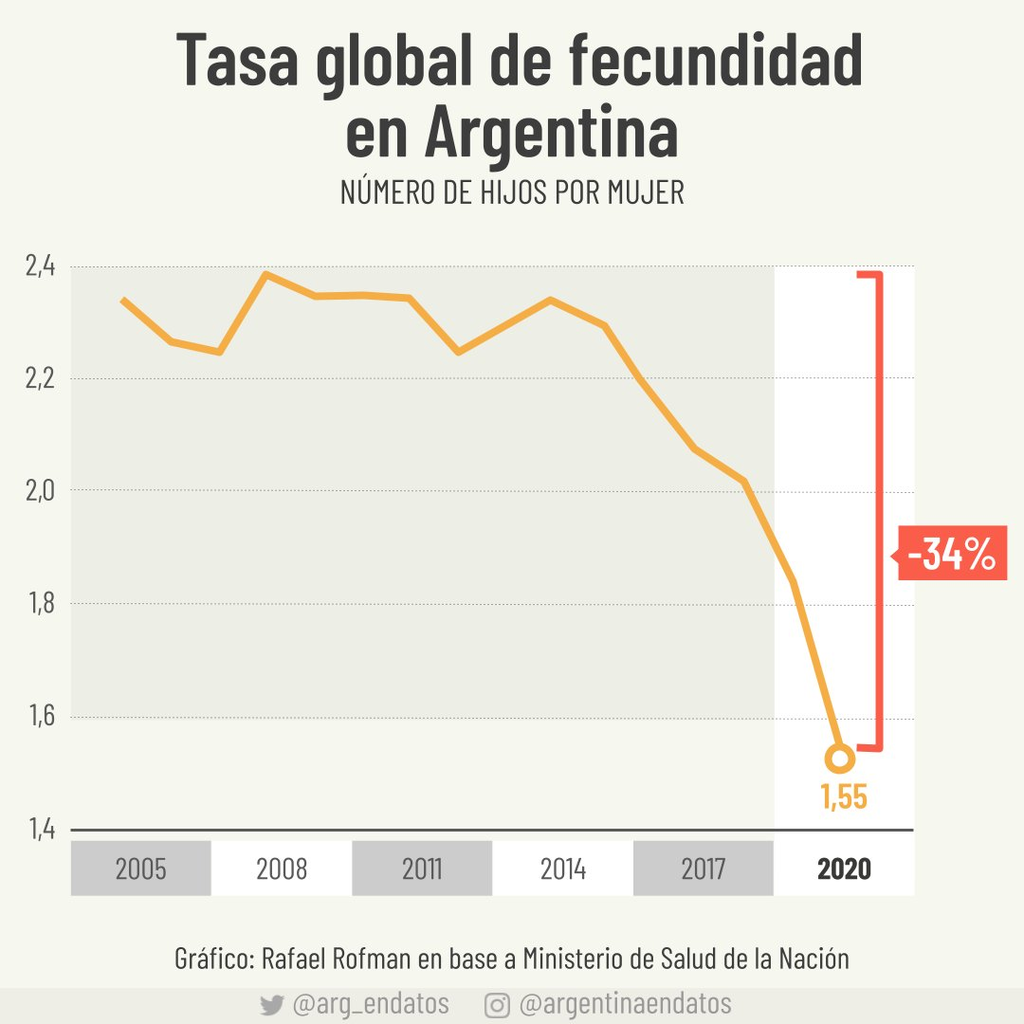

Fuente: www.twing.com. Situación de nuestro pais.

**3)** ¿Qué relación tiene una tasa por abajo de 2,1 con la salud pública?